# ZDTBCG BPNet in silico injection summaries

Kaelan (1028-02098-001-001)

July 19, 2022

# 1. Introduction

The goal of this analysis is to show summaries for the in silico injections using the motifs for our TFs of interest from the ZDTBCG model. In the previous .ipynb, we injected the Zelda and GAF motifs at variable distances from patterning TF motifs and predicted the binding of all TFs. This addresses the question “if motifX is moved away from Zelda, does that motif bind worse than if it is closer to Zelda?” Here, we will summarize these results into line plots. This analysis encompasses Figure 1f.

# 2. Computational Setup

```r
#Standard packages
library(rtracklayer) ; library(GenomicRanges); library(magrittr) ; library(Biostrings)
library(ggplot2) ; library(reshape2); library(plyranges); library(Rsamtools); library(ggpubr)
library(dplyr); library(data.table); library(patchwork); library(readr); library(testit); library(cowplot)

#KNITR Options
setwd("/l/Zeitlinger/ZeitlingerLab/Manuscripts/Zelda_and_Nucleosomes/Analysis/analysis/")
options(knitr.figure_dir="figures/6a_plot_insilico_distances/", java.parameters = "- Xmx6g")

#Lab sources
source("scripts/r/granges_common.r")
source("scripts/r/metapeak_common.r")
source("scripts/r/knitr_common.r")
source("scripts/r/caching.r")
source("scripts/r/metapeak_functions.r")

#Specific sources
library(ggseqlogo)
library(BSgenome.Dmelanogaster.UCSC.dm6)
library(rhdf5)
source("scripts/r/motif_functions.r")

#Pre-existing variables
modisco_dir <- 'bpnet/modisco/fold1/'
tasks <- c('Zld','Dl','Twi','Bcd','Cad','GAF')
threads <- 5
bsgenome<-BSgenome.Dmelanogaster.UCSC.dm6
```

# Import in silico injections

Here, in `6_*.ipynb` we measured the pairwise differences when putting every motif at a distances within 400bp of each other. We measured the central window between 400-600 for every comparison, so the central motif is the feature that is measured each time.

Note that we get negative counts predictions because we “correct for shoulder effects”, which is: AB - (B - 0).

Where: - AB: contains both, central and side_motif - B : contains only side_motif - 0 : doesn’t contain any motif

A short glossary of column terms from the BPNet code base. Keep in mind `alt` is the sequence with the central and side motif injected. `Ref` is the sequence is the central motif only.

```python
def profile_sim_metrics(ref, alt, pc=0):
    d = {}
    d['simmetric_kl'] = simmetric_kl(ref, alt).mean() - simmetric_kl(ref, ref).mean()
    d['counts'] = alt.sum()
    d['counts_frac'] = (alt.sum() + pc) / (ref.sum() + pc)
    d['max'] = alt.max()
    d['max_frac'] = (alt.max() + pc) / (ref.max() + pc)

    max_idx = np.argmax(ref, axis=0)
    d['counts_max_ref'] = alt[max_idx, [0, 1]].sum()
    d['counts_max_ref_frac'] = (d['counts_max_ref'] + pc) / (ref[max_idx, [0, 1]].sum() + pc)
    return d
```

Here, we will import the predictions and define variables

```r
preds.df <- readr::read_tsv('/l/Zeitlinger/ZeitlingerLab/Manuscripts/Zelda_and_Nucleosomes/Analysis/analysis/tsv/perturbs/binding/insilico/insilico_summaries.tsv.gz') %>% as.data.frame()
preds.df %>% head
```

```
##   ...1 profile/simmetric_kl profile/counts profile/counts_frac profile/max
## 1    0          0.006858649      227.14993           0.6929235   0.7440162
## 2    1          0.008102221      179.51239           0.6470712   0.5789198
## 3    2          0.005470435       87.67381           0.7653718   0.2625675
## 4    3                  Inf       41.21671           0.7776284   0.6329960
## 5    4          0.030250626       93.34846           0.5847061   0.3635909
## 6    5          0.011914756      202.25656           0.5258619   0.6779382
##   profile/max_frac profile/counts_max_ref profile/counts_max_ref_frac task
## 1        0.6118600              1.1549377                   0.5039361  Bcd
## 2        0.5226421              0.9155422                   0.4430974  Cad
## 3        0.5876372              0.4429826                   0.4983770   Dl
## 4        3.0889880              0.1527784                   0.3897572  GAF
## 5        0.5224589              0.5182857                   0.4100702  Twi
## 6        0.3430437              1.0517539                   0.2895880  Zld
##   central_motif side_motif position distance
## 1           Zld        GAF      505        5
## 2           Zld        GAF      505        5
## 3           Zld        GAF      505        5
## 4           Zld        GAF      505        5
## 5           Zld        GAF      505        5
## 6           Zld        GAF      505        5
```

```r
ZDTBCG.tasks <- c('Zld','Dl','Twi','Bcd','Cad','GAF')
ZDTBCG.color.vec<-c('#059AB1','#B90088','#5EB105','#500EB1','#B17A0E','#9E1C1F')
names(ZDTBCG.color.vec)<-ZDTBCG.tasks
```

# Filter predictions to focus on Zelda

Here, our goal is to see how other motifs react when moving further from Zelda. This means we need to (1) filter out all pairs that don’t involve Zelda and the pairs that don’t measure across the other motifs and (2) make sure each task is being measured that matches its own motif. Additionally, add some columns to log-scale your results.

```r
preds_depending_on_zld.df<-preds.df %>%
  dplyr::filter(side_motif=='Zld', central_motif==task, distance >=20) %>%
  dplyr::group_by(central_motif) %>%
  dplyr::arrange(distance) %>%
  dplyr::mutate(log2_fc_max = log2(`profile/counts_max_ref_frac`),
                log2_fc_sum = log2(`profile/counts_frac`))
```

# Plot results to see how TFs react to Zelda distance

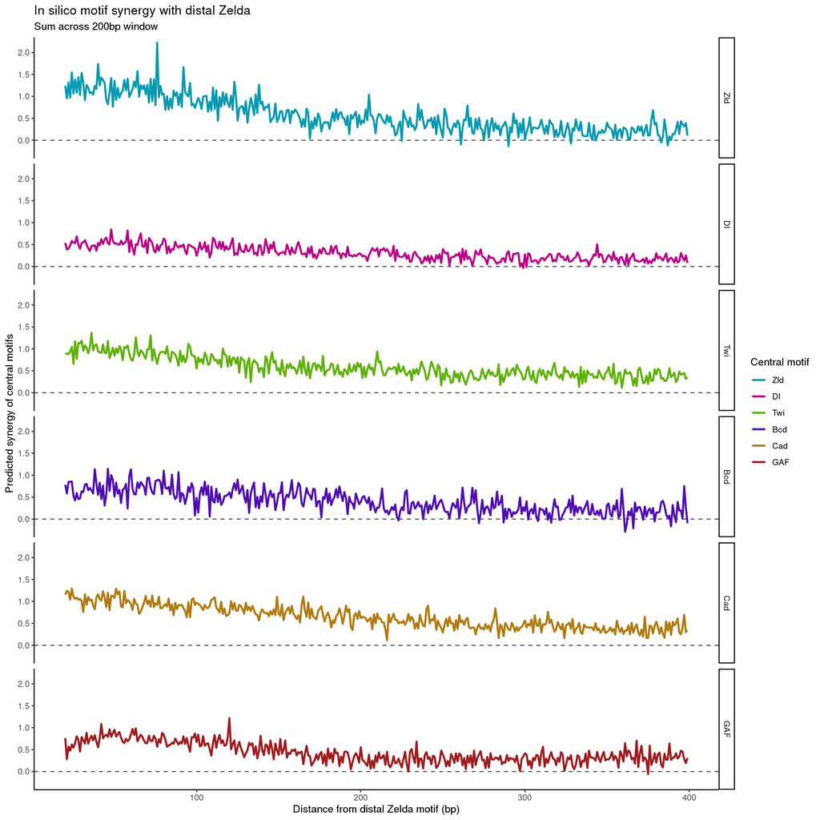

```r
preds_depending_on_zld.df$central_motif<-factor(preds_depending_on_zld.df$central_motif, levels = ZDTBCG.tasks)

sum_log2fc.plot<-ggplot(preds_depending_on_zld.df, aes(x = distance, y = log2_fc_sum, color = central_motif))+
  geom_hline(yintercept = 0, linetype = 'dashed', color = 'gray30')+
  geom_line(size = 1)+
  scale_x_continuous(name = 'Distance from distal Zelda motif (bp)')+
  scale_y_continuous(name = 'Predicted synergy of central motifs')+
  scale_color_manual(values = ZDTBCG.color.vec, name = 'Central motif')+
  facet_grid(central_motif ~ .) +
  ggtitle('In silico motif synergy with distal Zelda', subtitle = 'Sum across 200bp window')+
  theme_classic()
sum_log2fc.plot
```

```r
ggsave('figures/6a_plot_insilico_distances/in_silico_zelda_partner_synergy.png', sum_log2fc.plot, height = 8, width = 6)
ggsave('figures/6a_plot_insilico_distances/in_silico_zelda_partner_synergy.pdf', sum_log2fc.plot, height = 8, width = 6)
```